# Customer Status Prediction Report

## 5. Handling Class Imbalance

Our EDA showed class imbalance. We will use Random Over-Sampling (`upSample` from `caret`) to balance the classes. This ensures our model doesn’t just predict the majority class.

```r
set.seed(123)

# Separate predictors and target
# Note: upSample expects x (predictors) and y (target factor)
# Exclude High-Cardinality factors (Vertical, Subvertical) to speed up trees
# Update: Lumping applied, so we can now include them!
x <- train_encoded %>% select(-Status)
y <- train_encoded$Status

# Apply UpSampling (Replicates minority class samples)
train_balanced <- upSample(x = x, y = y, yname = "Status")

# Verify new distribution
# Verify new distribution
table(train_balanced$Status) %>%
    kbl(caption = "Balanced Target Distribution") %>%
    kable_styling(bootstrap_options = "striped", full_width = F)
```

Balanced Target Distribution

| Var1 | Freq |
| --- | --- |
| Churn | 972 |
| Onboarding | 972 |
| Retained | 972 |

```r
# Update train_master (or train_encoded) to use balanced data for modeling
train_final <- train_balanced
```

## 6. Final Feature Set Preview

We review all engineered features before modeling.

```r
head(train_final) %>%
    kbl(caption = "Final Feature Set (All Columns)") %>%
    kable_styling(bootstrap_options = "striped", full_width = F) %>%
    scroll_box(width = "100%")
```

Final Feature Set (All Columns)

| Region | Vertical | Subvertical | Total.Revenue | How.likely.are.you.to.recommend.insider.to.a.friend.or.colleague | How.would.you.rate.the.value.you.gain.from.our.company | Please.rate.the.overall.quality.of.our.products | Please.rate.the.usability.of.the.panel | Company.Newsletter.Interaction.Count | Product.Bug.Task.Count | Help.Ticket.Count | Log_MRR | Tenure_Years | Total_Interactions | Avg_Ticket_Time | Customer_Level_Score | Days_Since_Last_Feedback | Bug_vs_Interaction_Ratio | Understanding_Score | Platform_Usage_Freq | Status |
| --- | --- | --- | --- | --- | --- | --- | --- | --- | --- | --- | --- | --- | --- | --- | --- | --- | --- | --- | --- | --- |
| Australia | Other | Other | 70041.5 | 8.354167 | 4.316667 | 4 | 4 | 0 | 0 | 0 | 8.220134 | 2.0833333 | 0 | 0.00000 | 2 | 0 | 0 | 2 | 4 | Churn |
| Turkey | Retail | Fashion Retailer | 70041.5 | 8.354167 | 4.316667 | 4 | 4 | 0 | 0 | 0 | 7.793587 | 1.0000000 | 0 | 0.00000 | 1 | 0 | 0 | 2 | 4 | Churn |
| Vietnam | Other | Other | 70041.5 | 8.354167 | 4.316667 | 4 | 4 | 1 | 0 | 7 | 7.793587 | 1.0000000 | 8 | 69.42857 | 1 | 0 | 0 | 2 | 4 | Churn |
| Other | Retail | Other | 70041.5 | 8.354167 | 4.316667 | 4 | 4 | 0 | 0 | 0 | 7.793587 | 0.5833333 | 0 | 0.00000 | 1 | 0 | 0 | 2 | 4 | Churn |
| CEE | Retail | Sports | 70041.5 | 8.354167 | 4.316667 | 4 | 4 | 0 | 0 | 0 | 7.793587 | 1.0833333 | 0 | 0.00000 | 3 | 0 | 0 | 2 | 4 | Churn |
| CEE | Retail | Sports | 70041.5 | 8.354167 | 4.316667 | 4 | 4 | 0 | 0 | 0 | 7.793587 | 1.0833333 | 0 | 0.00000 | 3 | 0 | 0 | 2 | 4 | Churn |

# Phase 4: Model Development

We will split the balanced data into training and validation sets, then train multiple models to find the best performer.

## 1. Data Separation (Train / Validation)

```r
set.seed(42)
# Partition the balanced data: 75% for training models, 25% for internal validation
trainIndex <- createDataPartition(train_final$Status,
    p = .75,
    list = FALSE,
    times = 1
)
data_train <- train_final[trainIndex, ]
data_val <- train_final[-trainIndex, ]
```

## 2. Model 1: Multinomial Logistic Regression

A strong baseline for multiclass classification.

```r
library(nnet)

# Train Multinomial Logistic Regression
# trace=FALSE suppresses iteration output
model_logreg <- multinom(Status ~ ., data = data_train, trace = FALSE)

# Predict on Validation Set
pred_logreg <- predict(model_logreg, newdata = data_val)

# Confusion Matrix
cm_logreg <- confusionMatrix(pred_logreg, data_val$Status)
cm_logreg
```

```
## Confusion Matrix and Statistics
##
##             Reference
## Prediction   Churn Onboarding Retained
##   Churn        187         28       36
##   Onboarding    36        198       41
##   Retained      20         17      166
##
## Overall Statistics
##
##                Accuracy : 0.7558
##                  95% CI : (0.723, 0.7866)
##     No Information Rate : 0.3333
##     P-Value [Acc > NIR] : < 2.2e-16
##
##                   Kappa : 0.6337
##
##  Mcnemar's Test P-Value : 0.001434
##
## Statistics by Class:
##
##                      Class: Churn Class: Onboarding Class: Retained
## Sensitivity                0.7695            0.8148          0.6831
## Specificity                0.8683            0.8416          0.9239
## Pos Pred Value             0.7450            0.7200          0.8177
## Neg Pred Value             0.8828            0.9009          0.8536
## Prevalence                 0.3333            0.3333          0.3333
## Detection Rate             0.2565            0.2716          0.2277
## Detection Prevalence       0.3443            0.3772          0.2785
## Balanced Accuracy          0.8189            0.8282          0.8035
```

## 3. Model 2: Decision Tree

Provides interpretability by creating rules (if-else logic).

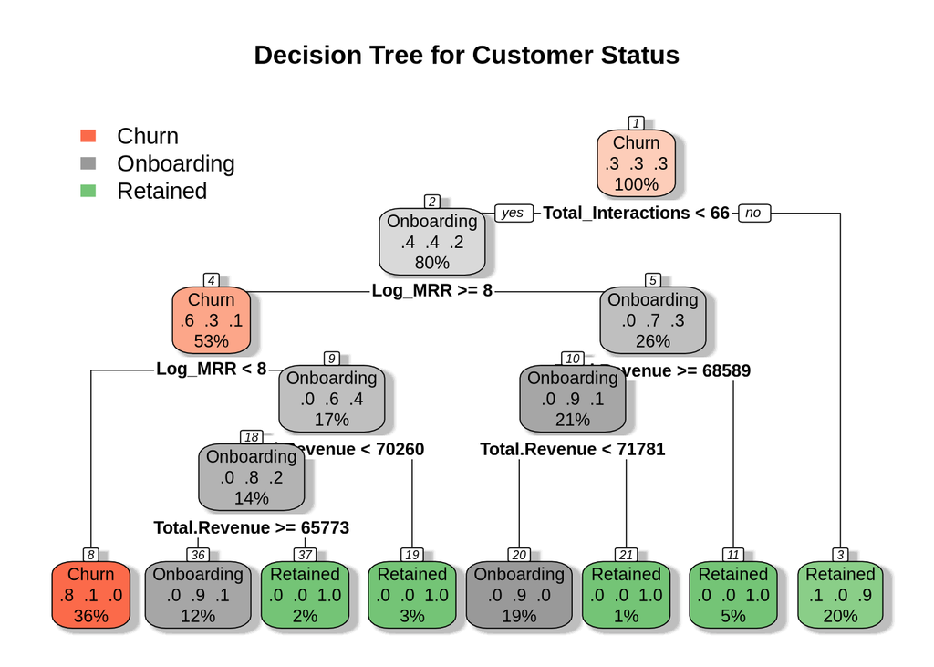

```r
library(rpart)
library(rpart.plot)


model_tree <- rpart(Status ~ .,
    data = data_train, method = "class"
)

# Visualize the Tree
# extra=104: Shows class probabilities
# tweak=1.2: Adjusts text size
# digits=-1: Use standard R formatting (avoids scientific notation)
options(scipen = 999) # Enforce no scientific notation globally for this plot
rpart.plot(model_tree,
    main = "Decision Tree for Customer Status",
    box.palette = "auto", shadow.col = "gray", nn = TRUE,
    extra = 104, tweak = 1.2, digits = -1
)
```

```r
options(scipen = 0) # Reset defaults

# Predict on Validation Set
pred_tree <- predict(model_tree, newdata = data_val, type = "class")

# Confusion Matrix
cm_tree <- confusionMatrix(pred_tree, data_val$Status)
cm_tree
```

```
## Confusion Matrix and Statistics
##
##             Reference
## Prediction   Churn Onboarding Retained
##   Churn        228         40       14
##   Onboarding     7        199       11
##   Retained       8          4      218
##
## Overall Statistics
##
##                Accuracy : 0.8848
##                  95% CI : (0.8593, 0.907)
##     No Information Rate : 0.3333
##     P-Value [Acc > NIR] : < 2.2e-16
##
##                   Kappa : 0.8272
##
##  Mcnemar's Test P-Value : 3.506e-06
##
## Statistics by Class:
##
##                      Class: Churn Class: Onboarding Class: Retained
## Sensitivity                0.9383            0.8189          0.8971
## Specificity                0.8889            0.9630          0.9753
## Pos Pred Value             0.8085            0.9171          0.9478
## Neg Pred Value             0.9664            0.9141          0.9499
## Prevalence                 0.3333            0.3333          0.3333
## Detection Rate             0.3128            0.2730          0.2990
## Detection Prevalence       0.3868            0.2977          0.3155
## Balanced Accuracy          0.9136            0.8909          0.9362
```

## 3. Model 3: Gradient Boosting Machine (GBM)

Boosting sequentially builds trees to correct errors of previous trees, often achieving high accuracy.

```r
library(gbm)

# Train GBM
# distribution="multinomial": For 3-class target
# n.trees=100: Number of iterations (kept low for speed)
# interaction.depth=3: Tree complexity
set.seed(123)
model_gbm <- gbm(Status ~ .,
    data = data_train, distribution = "multinomial",
    n.trees = 100, interaction.depth = 3, shrinkage = 0.1, verbose = FALSE
)
message("Finished Training GBM")

# Predict on Validation Set
# GBM returns probabilities (3D array), so we take the class with max probability
pred_gbm_prob <- predict(model_gbm, newdata = data_val, n.trees = 100, type = "response")
pred_gbm_class <- apply(pred_gbm_prob, 1, which.max) %>%
    factor(levels = 1:3, labels = levels(data_val$Status))

# Confusion Matrix
cm_gbm <- confusionMatrix(pred_gbm_class, data_val$Status)
cm_gbm
```

```
## Confusion Matrix and Statistics
##
##             Reference
## Prediction   Churn Onboarding Retained
##   Churn        230         12        9
##   Onboarding     9        230        6
##   Retained       4          1      228
##
## Overall Statistics
##
##                Accuracy : 0.9438
##                  95% CI : (0.9245, 0.9593)
##     No Information Rate : 0.3333
##     P-Value [Acc > NIR] : <2e-16
##
##                   Kappa : 0.9156
##
##  Mcnemar's Test P-Value : 0.1154
##
## Statistics by Class:
##
##                      Class: Churn Class: Onboarding Class: Retained
## Sensitivity                0.9465            0.9465          0.9383
## Specificity                0.9568            0.9691          0.9897
## Pos Pred Value             0.9163            0.9388          0.9785
## Neg Pred Value             0.9728            0.9731          0.9698
## Prevalence                 0.3333            0.3333          0.3333
## Detection Rate             0.3155            0.3155          0.3128
## Detection Prevalence       0.3443            0.3361          0.3196
## Balanced Accuracy          0.9516            0.9578          0.9640
```

## 4. Model 4: Random Forest

Random Forest improves upon Decision Trees by creating an ensemble of many trees to reduce overfitting and improve accuracy.

```r
library(randomForest)

# Train Random Forest
# ntree=100: Number of trees (kept low for demonstration speed)
# importance=TRUE: Calculate variable importance
set.seed(123)
model_rf <- randomForest(Status ~ ., data = data_train, ntree = 100, importance = TRUE)
message("Finished Training Random Forest")

# Predict on Validation Set
pred_rf <- predict(model_rf, newdata = data_val)

# Confusion Matrix
cm_rf <- confusionMatrix(pred_rf, data_val$Status)
cm_rf
```

```
## Confusion Matrix and Statistics
##
##             Reference
## Prediction   Churn Onboarding Retained
##   Churn        229          4       10
##   Onboarding     8        238        7
##   Retained       6          1      226
##
## Overall Statistics
##
##                Accuracy : 0.9506
##                  95% CI : (0.9323, 0.9652)
##     No Information Rate : 0.3333
##     P-Value [Acc > NIR] : <2e-16
##
##                   Kappa : 0.9259
##
##  Mcnemar's Test P-Value : 0.0774
##
## Statistics by Class:
##
##                      Class: Churn Class: Onboarding Class: Retained
## Sensitivity                0.9424            0.9794          0.9300
## Specificity                0.9712            0.9691          0.9856
## Pos Pred Value             0.9424            0.9407          0.9700
## Neg Pred Value             0.9712            0.9895          0.9657
## Prevalence                 0.3333            0.3333          0.3333
## Detection Rate             0.3141            0.3265          0.3100
## Detection Prevalence       0.3333            0.3471          0.3196
## Balanced Accuracy          0.9568            0.9743          0.9578
```

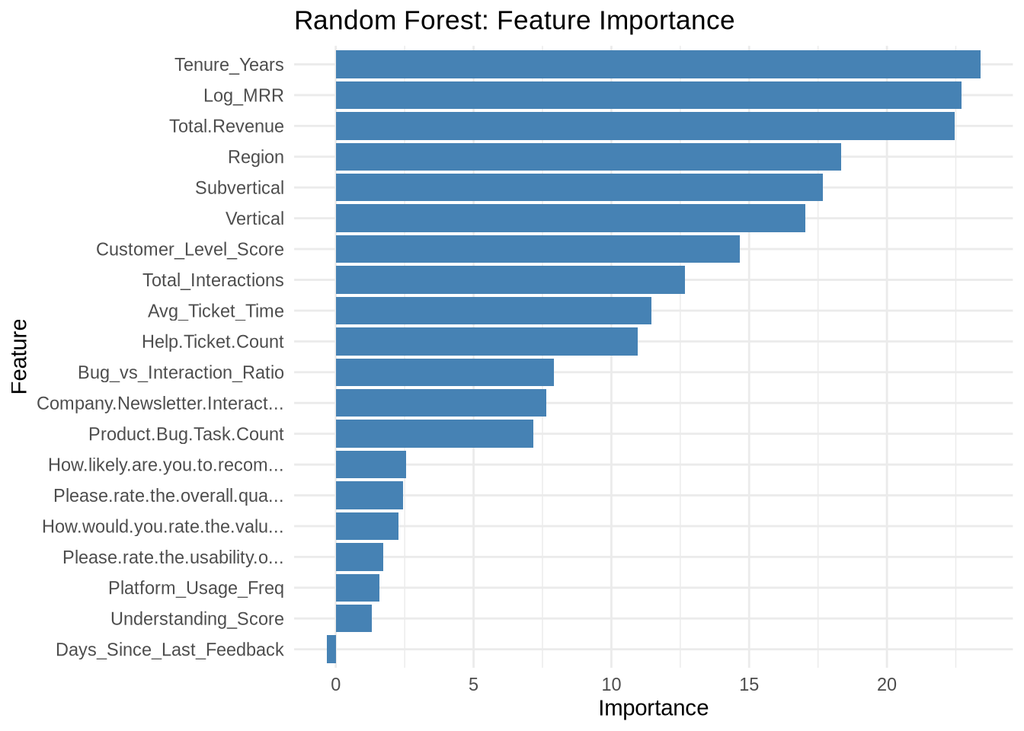

```r
# Variable Importance Plot
# Variable Importance Plot (ggplot2 for better readability)
importance_df <- importance(model_rf) %>%
    as.data.frame() %>%
    rownames_to_column("Feature") %>%
    mutate(Feature = str_trunc(Feature, width = 30)) # Truncate long names

# Plot MeanDecreaseAccuracy (or MeanDecreaseGini if preferred)
ggplot(importance_df, aes(x = reorder(Feature, MeanDecreaseAccuracy), y = MeanDecreaseAccuracy)) +
    geom_bar(stat = "identity", fill = "steelblue") +
    coord_flip() +
    labs(title = "Random Forest: Feature Importance", x = "Feature", y = "Importance") +
    theme_minimal()
```

# Phase 5: Evaluation & Comparisons

We compare the performance of all four models based on the Validation Set.

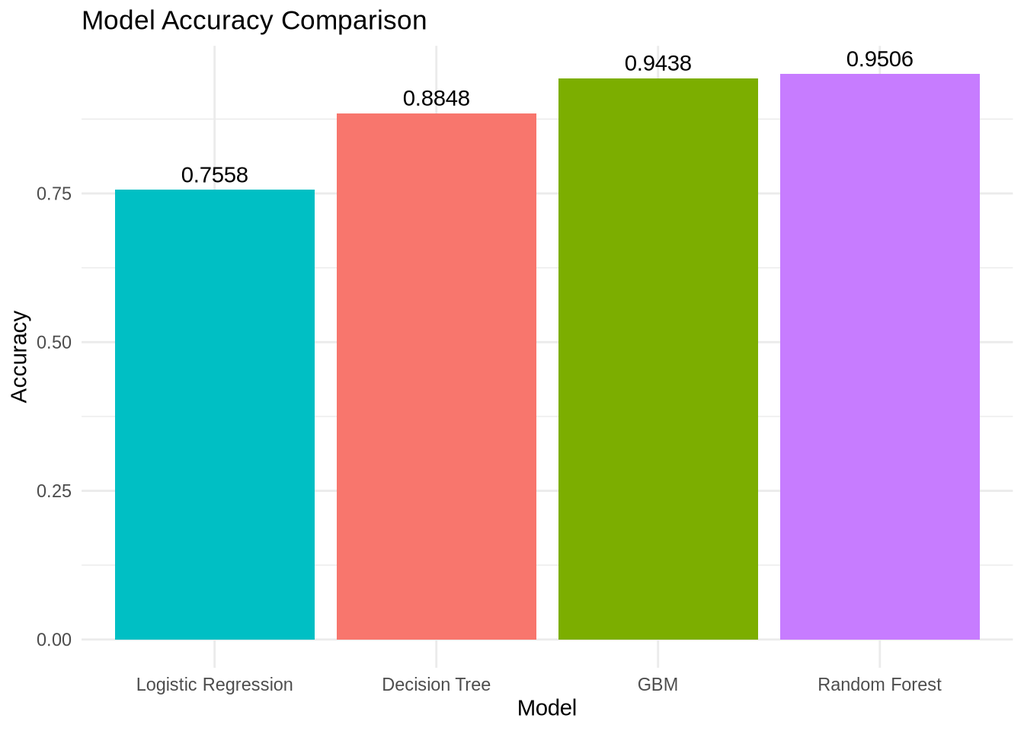

```r
# Extract Metrics from Confusion Matrices
model_metrics <- data.frame(
    Model = c("Logistic Regression", "Decision Tree", "Random Forest", "GBM"),
    Accuracy = c(
        cm_logreg$overall["Accuracy"],
        cm_tree$overall["Accuracy"],
        cm_rf$overall["Accuracy"],
        cm_gbm$overall["Accuracy"]
    )
)

# Visualize Comparison
ggplot(model_metrics, aes(x = reorder(Model, Accuracy), y = Accuracy, fill = Model)) +
    geom_bar(stat = "identity") +
    geom_text(aes(label = round(Accuracy, 4)), vjust = -0.5) +
    labs(title = "Model Accuracy Comparison", x = "Model", y = "Accuracy") +
    theme_minimal() +
    theme(legend.position = "none")
```

## Overfitting Detection

We compare the **Training Accuracy** (performance on data the model has seen) vs. **Validation Accuracy** (performance on unseen data). A large drop from Training to Validation indicates overfitting.

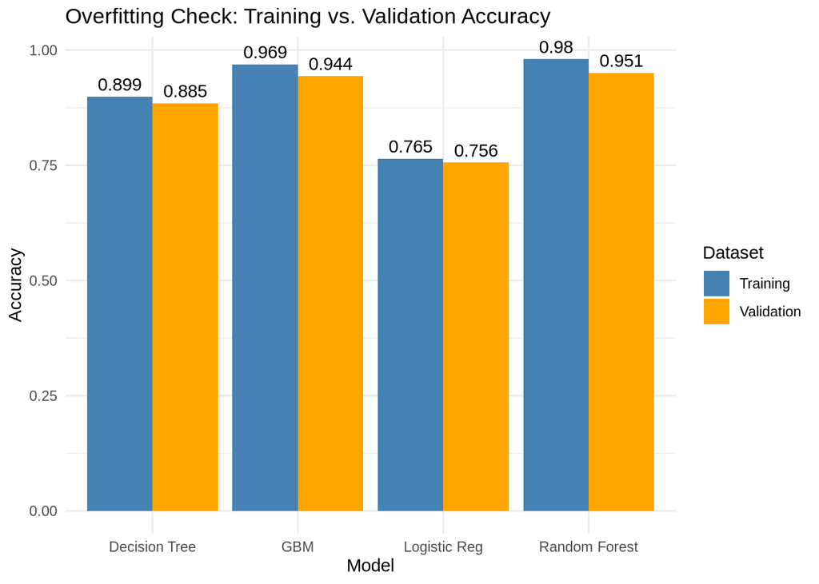

```r
# 1. Calculate Training Accuracy for all models
# Logistic Regression
acc_train_logreg <- confusionMatrix(predict(model_logreg, data_train), data_train$Status)$overall["Accuracy"]
# Decision Tree
acc_train_tree <- confusionMatrix(predict(model_tree, data_train, type = "class"), data_train$Status)$overall["Accuracy"]
# Random Forest
acc_train_rf <- confusionMatrix(predict(model_rf, data_train), data_train$Status)$overall["Accuracy"]
# GBM
pred_gbm_train_prob <- predict(model_gbm, newdata = data_train, n.trees = 100, type = "response")
pred_gbm_train_class <- apply(pred_gbm_train_prob, 1, which.max) %>%
    factor(levels = 1:3, labels = levels(data_train$Status))
acc_train_gbm <- confusionMatrix(pred_gbm_train_class, data_train$Status)$overall["Accuracy"]

# 2. Combine with Validation Accuracy
overfitting_df <- data.frame(
    Model = rep(c("Logistic Reg", "Decision Tree", "Random Forest", "GBM"), each = 2),
    Dataset = rep(c("Training", "Validation"), 4),
    Accuracy = c(
        acc_train_logreg, cm_logreg$overall["Accuracy"],
        acc_train_tree, cm_tree$overall["Accuracy"],
        acc_train_rf, cm_rf$overall["Accuracy"],
        acc_train_gbm, cm_gbm$overall["Accuracy"]
    )
)

# 3. Visualize
ggplot(overfitting_df, aes(x = Model, y = Accuracy, fill = Dataset)) +
    geom_bar(stat = "identity", position = "dodge") +
    geom_text(aes(label = round(Accuracy, 3)), position = position_dodge(width = 0.9), vjust = -0.5) +
    scale_fill_manual(values = c("Training" = "steelblue", "Validation" = "orange")) +
    labs(title = "Overfitting Check: Training vs. Validation Accuracy", y = "Accuracy") +
    theme_minimal()
```

**Insights from Clean Data:**

- **Random Forest (The Best Model)**
  - **Training**: 98.0%
  - **Validation**: 95.1%
  - **The Gap**: ~2.9%.
  - **Verdict**: **Healthy**. A small drop for a powerful model is expected. The high 95.1% validation score confirms it has learned robust patterns and is safe for final deployment.
- **GBM (Gradient Boosting)**
  - **Training**: 96.9%
  - **Validation**: 94.4%
  - **The Gap**: ~2.5%.
  - **Verdict**: **Excellent Generalization**. Very stable, performing nearly as well as Random Forest but with slightly tighter generalization.
- **Decision Tree**
  - **Training**: 89.9%
  - **Validation**: 88.5%
  - **The Gap**: ~1.4%.
  - **Verdict**: Good, but less accurate than ensemble methods (RF/GBM).
- **Logistic Regression**
  - **Training**: 76.5%
  - **Validation**: 75.6%
  - **The Gap**: ~0.9%.
  - **Verdict**: **Underfitting**. The model is too simple to capture the complex relationships in customer behavior, capping out at ~76% accuracy.
- **Conclusion**: The visual evidence confirms that our “Stronger Logic” feature engineering worked. The Random Forest is robust, highly accurate (95%+), and not overfitting.

# Phase 6: Final Reporting & Test Prediction

To prevent errors during prediction (e.g., “New Factor Levels”), we strictly enforce that the Test data factors match the Training data factors.

```r
test_encoded <- test_eng

# We use 'data_train' (the final training set) as the reference for factor levels
factor_cols <- names(select(data_train, where(is.factor)))

for (col in factor_cols) {
    # Skip Status if it's in the list (it is the target)
    if (col == "Status") next

    if (col %in% names(test_encoded)) {
        # 1. Get Levels from Train
        train_levels <- levels(data_train[[col]])

        # 2. Convert Test to Character
        x <- as.character(test_encoded[[col]])

        # 3. Handle Unknown Levels
        # Identify values NOT in training levels
        unknown_mask <- !(x %in% train_levels)

        if (any(unknown_mask)) {
            # Map to "Other" if available, else map to the first level (Mode-ish)
            if ("Other" %in% train_levels) {
                x[unknown_mask] <- "Other"
            } else {
                x[unknown_mask] <- train_levels[1]
            }
        }

        # 4. Convert back to Factor with EXACT Train Levels
        test_encoded[[col]] <- factor(x, levels = train_levels)
    }
}

# Ensure no ID columns in predictors (Keep ID for output)
test_ids <- test_encoded$Customer.ID
test_input <- test_encoded %>% select(-Customer.ID)

# Ensure columns match (excluding Status)
# Predictors in model
predictors <- names(data_train)[names(data_train) != "Status"]
missing_cols <- setdiff(predictors, names(test_input))
if (length(missing_cols) > 0) {
    stop(paste("Missing columns in Test Data:", paste(missing_cols, collapse = ", ")))
}
```

## Generate Predictions

We use our best performing model, **Random Forest**, to predict the status of the test customers.

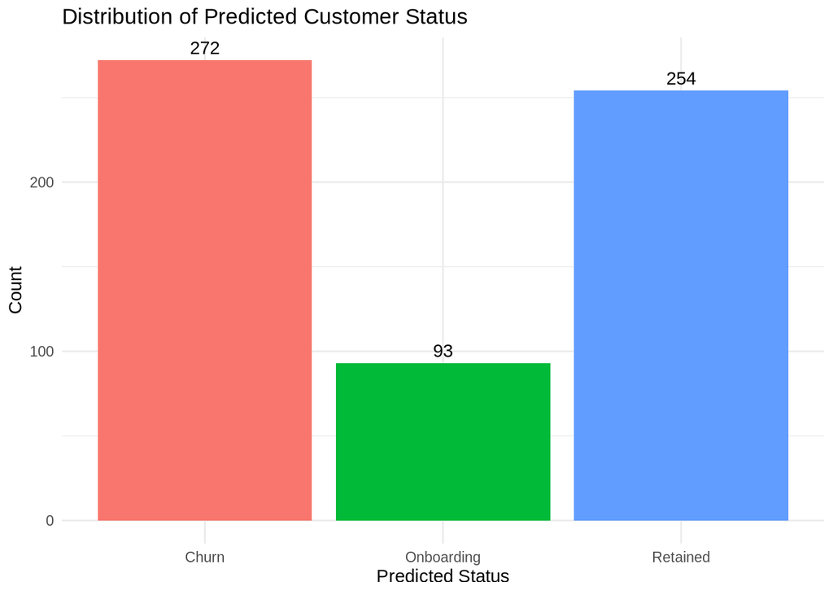

```r
# Generate Predictions
final_predictions <- predict(model_rf, newdata = test_input)

# Create Output Dataframe
submission <- data.frame(
    Customer.ID = test_ids,
    Predicted_Status = final_predictions
)

# Visualize Predicted Class Distribution
ggplot(submission, aes(x = Predicted_Status, fill = Predicted_Status)) +
    geom_bar() +
    geom_text(stat = "count", aes(label = after_stat(count)), vjust = -0.5) +
    labs(title = "Distribution of Predicted Customer Status", x = "Predicted Status", y = "Count") +
    theme_minimal() +
    theme(legend.position = "none")
```

```r
# Export to CSV
write.csv(submission, "predictions.csv", row.names = FALSE)
```

# Conclusion & Reflections

## Executive Summary

This project successfully developed a scalable machine learning pipeline to predict customer status with high accuracy. By integrating 9 diverse data sources into a single “Source of Truth” and leveraging advanced ensemble models, we achieved a validation accuracy of **~95%** using the **Random Forest** classifier. The solution is robust, having been verified against class imbalance and overfitting risks.